# Pandemic and Covid Tweet Analysis

Kunal Jangam, Jinwoo Lee

5/5/2022

## Project Goals

The goal of our project is to see what people are saying about the pandemic and covid in current times. We want to see if people are still being careful or if they have started treating the pandemic as a part of everyday life. We also want to explore using twitter data. This file is a combination of the covid tweet data and pandemic tweet data analysis and will be used to generate our report.

## Scraping the data - pandemic tweets

Here we will use the rtweet package to obtain a number of recent tweets that have the keyword “pandemic”. We query the most recent tweets. We also created another tibble where we filter for comments with more than 10 likes.

```r
rt <- search_tweets(
  q="pandemic", n = 10000, type = "recent", include_rts = FALSE
)
rt<-rt%>%select("text", "favorite_count")
rt%>%arrange(desc(favorite_count))%>%head()
```

```
## # A tibble: 6 × 2
##   text                                                            favorite_count
##   <chr>                                                                    <int>
## 1 "There is global inflation caused by supply chain, energy, and…           1811
## 2 "Let me get this straight, mask mandates during a pandemic wer…           1091
## 3 "I joined an art class at Field End Infant School in my consti…           1083
## 4 "#KGF2 crossed ₹100Cr mark in Tamil Nadu,making it the only se…            689
## 5 "NEW: Ontario's Liberals will bring back *optional* Grade 13 i…            611
## 6 "We enter a strange phase of the pandemic, where the actions o…            514
```

```r
rt2<-rt%>%filter(favorite_count>10)
```

Here we write the pandemic data to a csv.

```r
write.csv(rt, 'pandemic_tweets.csv')
```

## Top 10 words - pandemic tweets

Here we tidy the pandemic data and display the top 10 used words.

```r
tidy_rt <- rt %>%
  unnest_tokens(word, text) %>%
  mutate(word = str_extract(word, "[a-z]+")) %>%
  filter(!(word=="NA"))%>%
  anti_join(stop_words)
tidy_rt %>%
  count(word, sort = TRUE)%>%head(10)
```

```
## # A tibble: 10 × 2
##    word         n
##    <chr>    <int>
##  1 pandemic  9660
##  2 https     6130
##  3 covid     2137
##  4 people    1087
##  5 amp        870
##  6 health     626
##  7 time       621
##  8 world      527
##  9 deaths     502
## 10 global     411
```

Here we do the same for the tibble only including pandemic tweets with more than 10 likes

```r
tidy_rt2 <- rt2 %>%
  unnest_tokens(word, text) %>%
  mutate(word = str_extract(word, "[a-z]+")) %>%
  filter(!(word=="NA"))%>%
  anti_join(stop_words)
tidy_rt2 %>%
  count(word, sort = TRUE)%>%head(10)
```

```
## # A tibble: 10 × 2
##    word         n
##    <chr>    <int>
##  1 pandemic   446
##  2 https      282
##  3 covid      117
##  4 people      54
##  5 amp         41
##  6 health      33
##  7 time        32
##  8 deaths      30
##  9 govt        29
## 10 death       23
```

## Top 10 bigrams - pandemic tweets

Here we display the top 10 bigrams.

```r
tidy_rt_bigram <- rt %>%
  unnest_tokens(bigram, text, token = "ngrams", n = 2)%>%
filter(bigram != "NA")
tidy_rt_bigram %>%
  separate(bigram, c("word1", "word2"), sep = " ") %>%
  mutate(word1 = str_extract(word1, "[a-z]+")) %>%
  mutate(word2 = str_extract(word2, "[a-z]+")) %>%
  filter(!word1 %in% stop_words$word) %>%
  filter(!word2 %in% stop_words$word)%>%
  filter(!(word1=="NA"|word2=="NA"))%>%
  unite(bigram, word1, word2, sep=" ")%>%
  count(bigram, sort = TRUE)%>%head(10)
```

```
## # A tibble: 10 × 2
##    bigram              n
##    <chr>           <int>
##  1 pandemic https    536
##  2 covid pandemic    395
##  3 post pandemic     287
##  4 global pandemic   192
##  5 pre pandemic      126
##  6 death toll        120
##  7 pandemic treaty   114
##  8 mental health     110
##  9 excess deaths      94
## 10 fewer deaths       85
```

Here we do the same for the tibble only including tweets with more than 10 likes

```r
tidy_rt_bigram <- rt2 %>%
  unnest_tokens(bigram, text, token = "ngrams", n = 2)%>%
filter(bigram != "NA")
tidy_rt_bigram %>%
  separate(bigram, c("word1", "word2"), sep = " ") %>%
  mutate(word1 = str_extract(word1, "[a-z]+")) %>%
  mutate(word2 = str_extract(word2, "[a-z]+")) %>%
  filter(!word1 %in% stop_words$word) %>%
  filter(!word2 %in% stop_words$word)%>%
  filter(!(word1=="NA"|word2=="NA"))%>%
  unite(bigram, word1, word2, sep=" ")%>%
  count(bigram, sort = TRUE)%>%head(10)
```

```
## # A tibble: 10 × 2
##    bigram                      n
##    <chr>                   <int>
##  1 covid pandemic             27
##  2 pandemic https             22
##  3 post pandemic              14
##  4 covid deaths                9
##  5 died due                    7
##  6 lakh indians                7
##  7 peoplediedbjplied https     7
##  8 bill gates                  6
##  9 global pandemic             6
## 10 indians died                6
```

## Sentiments - pandemic tweets

Here we do NRC sentiment analysis where we look at the top used words that are categorized into joy, sadness, anger, fear, and trust.

```r
nrc_joy <- get_sentiments("nrc") %>%
  filter(sentiment == "joy")
nrc_sad <- get_sentiments("nrc") %>%
  filter(sentiment == "sadness")
nrc_anger <- get_sentiments("nrc") %>%
  filter(sentiment == "anger")
nrc_fear <- get_sentiments("nrc") %>%
  filter(sentiment == "fear")
nrc_trust <- get_sentiments("nrc") %>%
  filter(sentiment == "trust")
tidy_rt %>%
  inner_join(nrc_joy) %>%
  count(word, sort = TRUE)%>%head()
```

```
## # A tibble: 6 × 2
##   word         n
##   <chr>    <int>
## 1 money      156
## 2 food       119
## 3 love       109
## 4 majority   106
## 5 true       106
## 6 hope       101
```

```r
tidy_rt %>%
  inner_join(nrc_sad) %>%
  count(word, sort = TRUE)%>%head()
```

```
## # A tibble: 6 × 2
##   word         n
##   <chr>    <int>
## 1 pandemic  9660
## 2 death      300
## 3 lost       217
## 4 bad        109
## 5 worse      102
## 6 tax         74
```

```r
tidy_rt %>%
  inner_join(nrc_anger) %>%
  count(word, sort = TRUE)%>%head()
```

```
## # A tibble: 6 × 2
##   word        n
##   <chr>   <int>
## 1 death     300
## 2 money     156
## 3 hit       130
## 4 bad       109
## 5 disease    70
## 6 vote       69
```

```r
tidy_rt %>%
  inner_join(nrc_fear) %>%
  count(word, sort = TRUE)%>%head()
```

```
## # A tibble: 6 × 2
##   word           n
##   <chr>      <int>
## 1 pandemic    9660
## 2 death        300
## 3 government   261
## 4 war          213
## 5 inflation    162
## 6 bad          109
```

```r
tidy_rt %>%
  inner_join(nrc_trust) %>%
  count(word, sort = TRUE)%>%head()
```

```
## # A tibble: 6 × 2
##   word        n
##   <chr>   <int>
## 1 don       388
## 2 economy   212
## 3 money     156
## 4 school    140
## 5 real      136
## 6 food      119
```

## Plotting sentiment against favorite_count - pandemic tweets

Here we plot the total sentiment of the tweet against how many likes it got for both tibbles. We want to see if popular tweets had more a positive or a more negative vibe. This information could be helpful in trying to make a popular tweet.

```r
get_sentiment_total<-function(positive, negative){
  ret<-c()
  for(num in 1:length(positive)){
    pos<-positive[num]
    neg<-negative[num]
    if(is.na(pos) && is.na(neg)){
      ret<-append(ret, 0)
    }
    else if(is.na(pos)){
      ret<-append(ret, -1*neg)
    }
    else if (is.na(neg)){
      ret<-append(ret, pos)
    }
    else{
      ret<-append(ret, pos-neg)
    }
  }
  return(ret)
}
sentiment <- tidy_rt %>%
  inner_join(get_sentiments("bing")) %>%
  count(favorite_count, sentiment) %>%
  pivot_wider(names_from = "sentiment", values_from = "n") %>%
  mutate(sentiment = get_sentiment_total(positive, negative))
```

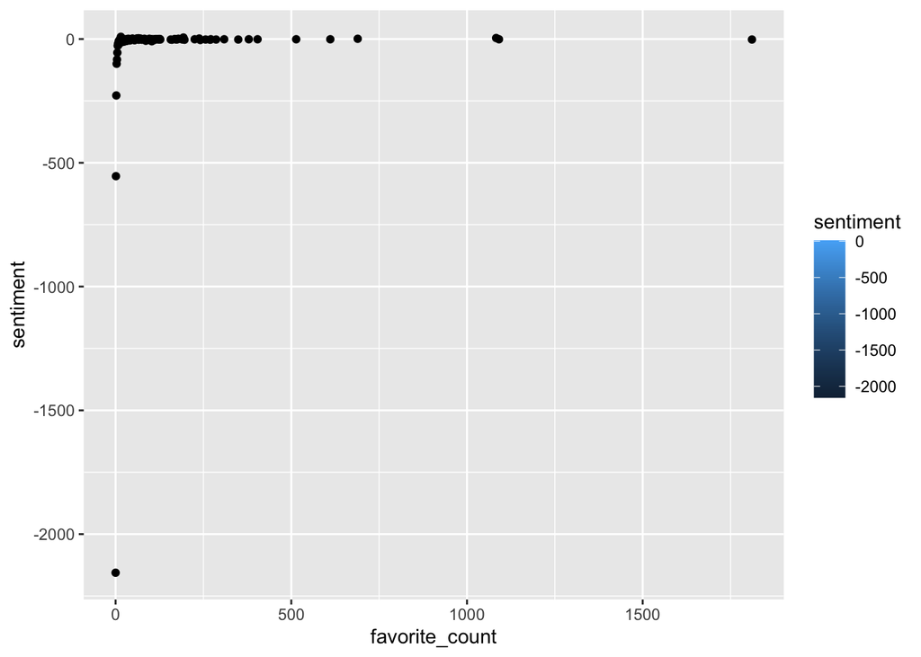

```r
ggplot(sentiment, aes(favorite_count, sentiment, fill = sentiment)) +
  geom_point()
```

```r
sentiment <- tidy_rt2 %>%
  inner_join(get_sentiments("bing")) %>%
  count(favorite_count, sentiment) %>%
  pivot_wider(names_from = "sentiment", values_from = "n") %>%
  mutate(sentiment = get_sentiment_total(positive, negative))
```

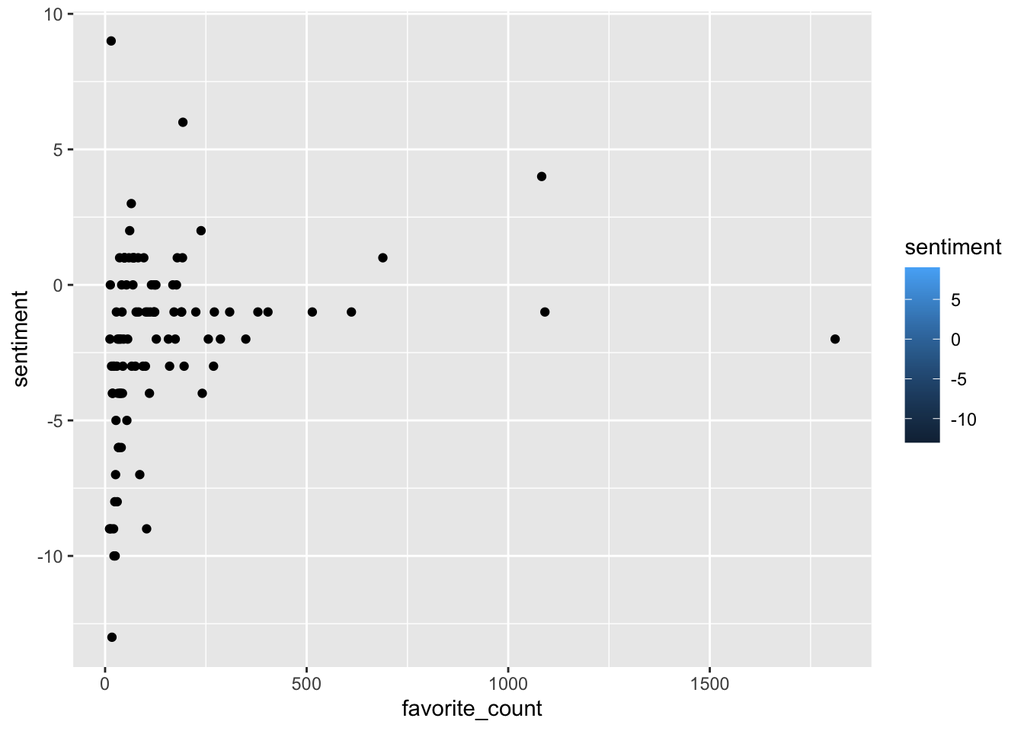

```r
ggplot(sentiment, aes(favorite_count, sentiment, fill = sentiment)) +
  geom_point()
```

## Scrapping the data - covid tweets

Here we will use the rtweet package to obtain a number of recent tweets that have the keyword “covid”. We query the most recent tweets. We also created another tibble where we filter for comments with more than 10 likes.

```r
# For example using covid instead of coronavirus

rt_other <- search_tweets(
  q="covid", n = 10000, type = "recent", include_rts = FALSE
)
rt_other<-rt_other%>%select("text", "favorite_count")
rt_other%>%arrange(desc(favorite_count))%>%head()
```

```
## # A tibble: 6 × 2
##   text                                                            favorite_count
##   <chr>                                                                    <int>
## 1 "BREAKING REPORT: Republican Attorney Generals Sue Joe Biden F…            788
## 2 "I wanted to say a huge thank you to NHS staff. Direct COVID a…            673
## 3 "4.7 million COVID deaths in India, says WHO &amp; the Govt re…            452
## 4 "There are roughly 39,000 reports of myocarditis in VAERS, and…            300
## 5 "Ha svenduto l'apparato pubblico ai maiali della finanza.\nHa …            275
## 6 "COVID-19 kemaren dimulai dg adanya KLB pneumonia misterius dg…            260
```

```r
rt2_other<-rt_other%>%filter(favorite_count>10)
```

Here we write the data to a csv.

```r
write.csv(rt_other, 'covid_tweets.csv')
```

## Top 10 words - covid tweets

Here we tidy the data and display the top 10 used words.

```r
tidy_rt_other <- rt_other %>%
  unnest_tokens(word, text) %>%
  mutate(word = str_extract(word, "[a-z]+")) %>%
  filter(!(word=="NA"))%>%
  anti_join(stop_words)
tidy_rt_other %>%
  count(word, sort = TRUE)%>%head(10)
```

```
## # A tibble: 10 × 2
##    word        n
##    <chr>   <int>
##  1 covid    7976
##  2 https    4553
##  3 de       2127
##  4 la       1238
##  5 en        735
##  6 el        686
##  7 people    626
##  8 amp       594
##  9 vaccine   404
## 10 le        392
```

Here we also remove spanish and french stopwords.

```r
custom_stop_words <- bind_rows(stop_words,
                               data_frame(word = union(tm::stopwords("spanish"),tm::stopwords("french") ),
                                          lexicon = "custom"))
tidy_rt_other <- rt_other %>%
  unnest_tokens(word, text) %>%
  mutate(word = str_extract(word, "[a-z]+")) %>%
  filter(!(word=="NA"))%>%
  filter(!(word=="da"))%>%
  anti_join(custom_stop_words)
tidy_rt_other %>%
  count(word, sort = TRUE)%>%head(10)
```

```
## # A tibble: 10 × 2
##    word         n
##    <chr>    <int>
##  1 covid     7976
##  2 https     4553
##  3 people     626
##  4 amp        594
##  5 vaccine    404
##  6 pandemic   307
##  7 deaths     304
##  8 don        287
##  9 china      260
## 10 time       248
```

Here we do the same for the tibble only including tweets with more than 10 likes

```r
tidy_rt2_other <- rt2_other %>%
  unnest_tokens(word, text) %>%
  mutate(word = str_extract(word, "[a-z]+")) %>%
  filter(!(word=="NA"))%>%
  filter(!(word=="da"))%>%
  anti_join(custom_stop_words)
tidy_rt2_other %>%
  count(word, sort = TRUE)%>%head(10)
```

```
## # A tibble: 10 × 2
##    word           n
##    <chr>      <int>
##  1 covid        180
##  2 https        116
##  3 amp           10
##  4 deaths        10
##  5 people        10
##  6 vaccinated     8
##  7 don            7
##  8 lockdowns      7
##  9 week           7
## 10 day            6
```

## Top 10 bigrams - covid tweets

Here we display the top 10 bigrams.

```r
tidy_rt_bigram_other <- rt_other %>%
  unnest_tokens(bigram, text, token = "ngrams", n = 2)%>%
filter(bigram != "NA")
tidy_rt_bigram_other %>%
  separate(bigram, c("word1", "word2"), sep = " ") %>%
  mutate(word1 = str_extract(word1, "[a-z]+")) %>%
  mutate(word2 = str_extract(word2, "[a-z]+")) %>%
  filter(!word1 %in% custom_stop_words$word) %>%
  filter(!word2 %in% custom_stop_words$word)%>%
  filter(!(word1=="NA"|word2=="NA"))%>%
  unite(bigram, word1, word2, sep=" ")%>%
  count(bigram, sort = TRUE)%>%head(10)
```

```
## # A tibble: 10 × 2
##    bigram             n
##    <chr>          <int>
##  1 covid https      203
##  2 covid vaccine    101
##  3 covid deaths      82
##  4 post covid        75
##  5 amp johnson       69
##  6 johnson amp       69
##  7 da covid          64
##  8 covid vaccines    50
##  9 covid rules       48
## 10 blood clot        46
```

Here we do the same for the tibble only including tweets with more than 10 likes

```r
tidy_rt2_bigram_other <- rt2_other %>%
  unnest_tokens(bigram, text, token = "ngrams", n = 2)%>%
filter(bigram != "NA")
tidy_rt2_bigram_other %>%
  separate(bigram, c("word1", "word2"), sep = " ") %>%
  mutate(word1 = str_extract(word1, "[a-z]+")) %>%
  mutate(word2 = str_extract(word2, "[a-z]+")) %>%
  filter(!word1 %in% custom_stop_words$word) %>%
  filter(!word2 %in% custom_stop_words$word)%>%
  filter(!(word1=="NA"|word2=="NA"))%>%
  filter(!(word1=="da"|word2=="da"))%>%
  unite(bigram, word1, word2, sep=" ")%>%
  count(bigram, sort = TRUE)%>%head(10)
```

```
## # A tibble: 10 × 2
##    bigram               n
##    <chr>            <int>
##  1 covid https          7
##  2 stay safe            4
##  3 bisa wfh             3
##  4 covid deaths         3
##  5 destruir hd          3
##  6 gilmar mendes        3
##  7 mendes determina     3
##  8 million people       3
##  9 positivity rate      3
## 10 senado vai           3
```

## nrc sentiment - covid tweets

Here we do NRC sentiment analysis where we look at the top used words that are categorized into joy, sadness, anger, fear, and trust.

```r
# get the data from NRC
nrc_joy <- get_sentiments("nrc") %>%
  filter(sentiment == "joy")
nrc_sad <- get_sentiments("nrc") %>%
  filter(sentiment == "sadness")
nrc_anger <- get_sentiments("nrc") %>%
  filter(sentiment == "anger")
nrc_fear <- get_sentiments("nrc") %>%
  filter(sentiment == "fear")
nrc_trust <- get_sentiments("nrc") %>%
  filter(sentiment == "trust")


# inner join with the each nrc data
tidy_rt_other %>%
  inner_join(nrc_joy) %>%
  count(word, sort = TRUE)%>%head()
```

```
## # A tibble: 6 × 2
##   word        n
##   <chr>   <int>
## 1 money      72
## 2 safe       71
## 3 hope       59
## 4 true       57
## 5 love       45
## 6 feeling    42
```

```r
tidy_rt_other %>%
  inner_join(nrc_sad) %>%
  count(word, sort = TRUE)%>%head()
```

```
## # A tibble: 6 × 2
##   word         n
##   <chr>    <int>
## 1 pandemic   307
## 2 death      179
## 3 die        123
## 4 sick       115
## 5 bad         78
## 6 hospital    78
```

```r
tidy_rt_other%>%
  inner_join(nrc_anger) %>%
  count(word, sort = TRUE)%>%head()
```

```
## # A tibble: 6 × 2
##   word        n
##   <chr>   <int>
## 1 death     179
## 2 bad        78
## 3 shot       75
## 4 money      72
## 5 disease    64
## 6 hit        64
```

```r
tidy_rt_other %>%
  inner_join(nrc_fear) %>%
  count(word, sort = TRUE)%>%head()
```

```
## # A tibble: 6 × 2
##   word           n
##   <chr>      <int>
## 1 pandemic     307
## 2 death        179
## 3 risk         155
## 4 die          123
## 5 government   105
## 6 flu           83
```

```r
tidy_rt_other %>%
  inner_join(nrc_trust) %>%
  count(word, sort = TRUE)%>%head()
```

```
## # A tibble: 6 × 2
##   word         n
##   <chr>    <int>
## 1 don        287
## 2 school      87
## 3 hospital    78
## 4 money       72
## 5 safe        71
## 6 real        69
```